# Exp6_selectiveAnalysis_Feb2021

### 6. Block Analysis

The experimental trials were split into 4 blocks, further joined to have two main blocks and the data was analysed to check if the interaction differed across block. This blockcount does not include the headstart learn trials

```
**It shows that the effect is stronger in the first block. Although the statistics are not significant the trend looks like the effect is larger in block 1 compared to block 2. This can also be due to the fact  that the first block is preceded by the headstart learn trials.**
```

- **ANOVA**:

  | Effect | DFn | DFd | SSn | SSd | F | p | p<.05 | ges |
  | --- | --- | --- | --- | --- | --- | --- | --- | --- |
  | (Intercept) | 1 | 69 | 91928216 | 921495 | 6883 | 7.407e-71 | * | 0.9857 |
  | Saliency | 1 | 69 | 902.9 | 111623 | 0.5581 | 0.4576 |  | 0.0006765 |
  | Validity | 1 | 69 | 14432 | 143385 | 6.945 | 0.01037 | * | 0.0107 |
  | Saliency:Validity | 1 | 69 | 1184 | 157277 | 0.5194 | 0.4735 |  | 0.0008868 |

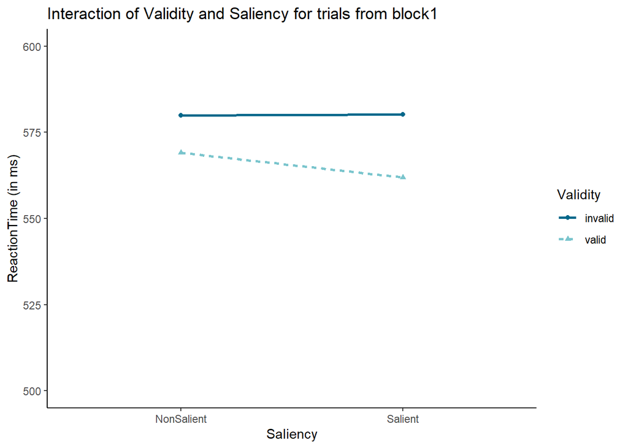

- **ANOVA**:

  | Effect | DFn | DFd | SSn | SSd | F | p | p<.05 | ges |
  | --- | --- | --- | --- | --- | --- | --- | --- | --- |
  | (Intercept) | 1 | 63 | 7.8e+07 | 748143 | 6568 | 2e-65 | * | 0.9868 |
  | Saliency | 1 | 63 | 2381 | 75738 | 1.981 | 0.1642 |  | 0.002285 |
  | Validity | 1 | 63 | 10534 | 96703 | 6.862 | 0.01102 | * | 0.01003 |
  | Saliency:Validity | 1 | 63 | 62.53 | 119141 | 0.03306 | 0.8563 |  | 6.013e-05 |

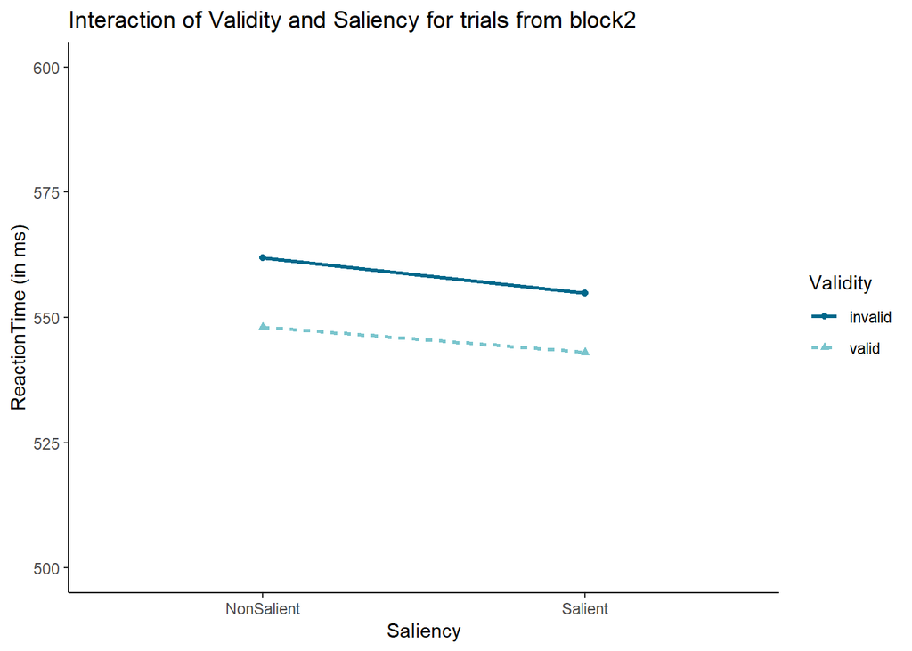

### Stimulus Response Binding Analysis

### 1. Overshadowing in the binding trials

First a variable is coded that looks at the SR pairs of learn-test trial where the test trial can either be a salient or a non salient letter. This variable is called the “OvershadowSRB” where 1 refers to Salient and 2 refers to non salient

#### Previous Response

Coding what the previous Response was, whether it was the same or different

Total number of RRs and RCs

| RC | RR |
| --- | --- |
| 7831 | 21148 |

```
##
## NonSalient    Salient
##       1112       1058
```

### ANOVA: Interaction between Response Type and OVershadowSRB, similar to Validity x Saliency but now in the binding level.

#### 1. Reaction time as dv

```
## [1] 6
```

[output not shown]

[output cut: 395 more lines]

```
##
##   1   2   3   4   5   6   7   8   9  12  13  14  15  16  19  21  22  23
##  30  26  27  29  36  24  33  28  36  31  37  24  29  37  27  29  33  31
##  24  26  27  30  32  33  34  35  36  37  38  40  42  43  44  46  47  48
##  33  43  32  37  28  29  39  36  28  30  28  28  28  29  28  32  33  29
##  49  50  51  52  55  57  58  59  60  61  62  63  64  65  66  67  68  69
##  37  38  31  27  31  27  26  37  36  30  27  27  24  23  29  29  27  34
##  70  71  72  79  81  82  83  85  86  87 107 108 109 110 113 114
##  31  28  28  34  35  33  33  33  34  29  26  33  29  32  35  40
```

```
##
## Error: participant
##                        Df  Sum Sq Mean Sq F value Pr(>F)
## Validity                1     411     411   0.023 0.8793
## OvershadowSRB           1   28428   28428   1.605 0.2097
## Validity:OvershadowSRB  1    6958    6958   0.393 0.5330
## Validity:ResponseType   1   53527   53527   3.022 0.0869 .
## Residuals              65 1151382   17714
## ---
## Signif. codes:  0 '***' 0.001 '**' 0.01 '*' 0.05 '.' 0.1 ' ' 1
##
## Error: participant:Validity
##                        Df Sum Sq Mean Sq F value Pr(>F)
## Validity                1  11204   11204   1.949  0.167
## OvershadowSRB           1    263     263   0.046  0.831
## ResponseType            1     53      53   0.009  0.924
## Validity:OvershadowSRB  1    255     255   0.044  0.834
## Validity:ResponseType   1   8308    8308   1.446  0.234
## Residuals              65 373554    5747
##
## Error: participant:OvershadowSRB
##                                     Df Sum Sq Mean Sq F value Pr(>F)
## OvershadowSRB                        1   1369    1369   0.311  0.579
## ResponseType                         1   1185    1185   0.269  0.606
## Validity:OvershadowSRB               1   2737    2737   0.622  0.433
## Validity:ResponseType                1   2619    2619   0.595  0.443
## Validity:OvershadowSRB:ResponseType  1   2756    2756   0.626  0.432
## Residuals                           65 286132    4402
##
## Error: participant:ResponseType
##                                     Df Sum Sq Mean Sq F value Pr(>F)
## ResponseType                         1   3315    3315   0.398  0.531
## Validity:OvershadowSRB               1   4811    4811   0.577  0.450
## Validity:ResponseType                1  12454   12454   1.495  0.227
## Validity:OvershadowSRB:ResponseType  1   1142    1142   0.137  0.713
## Residuals                           56 466483    8330
##
## Error: participant:Validity:OvershadowSRB
##                                     Df Sum Sq Mean Sq F value Pr(>F)
## Validity:OvershadowSRB               1     42      42   0.013  0.909
## Validity:ResponseType                1   5482    5482   1.710  0.196
## OvershadowSRB:ResponseType           1   5560    5560   1.734  0.192
## Validity:OvershadowSRB:ResponseType  1   4368    4368   1.362  0.247
## Residuals                           66 211595    3206
##
## Error: participant:Validity:ResponseType
##                                     Df Sum Sq Mean Sq F value Pr(>F)
## Validity:ResponseType                1    328     328   0.053  0.819
## OvershadowSRB:ResponseType           1    972     972   0.159  0.693
## Validity:OvershadowSRB:ResponseType  1  10593   10593   1.727  0.199
## Residuals                           29 177837    6132
##
## Error: participant:OvershadowSRB:ResponseType
##                                     Df Sum Sq Mean Sq F value Pr(>F)
## OvershadowSRB:ResponseType           1   6692    6692   0.656  0.425
## Validity:OvershadowSRB:ResponseType  1     51      51   0.005  0.944
## Residuals                           29 295736   10198
##
## Error: participant:Validity:OvershadowSRB:ResponseType
##                                     Df Sum Sq Mean Sq F value Pr(>F)
## Validity:OvershadowSRB:ResponseType  1   6216    6216    3.49  0.121
## Residuals                            5   8906    1781
```

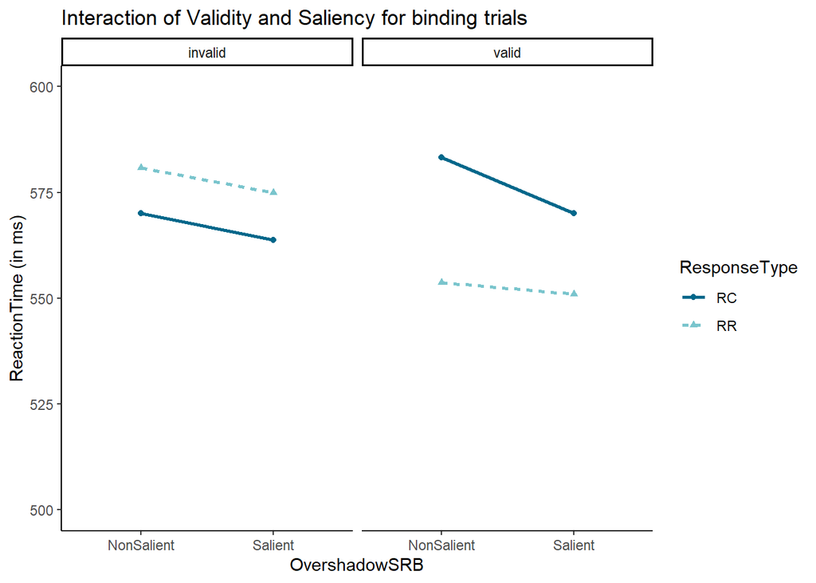

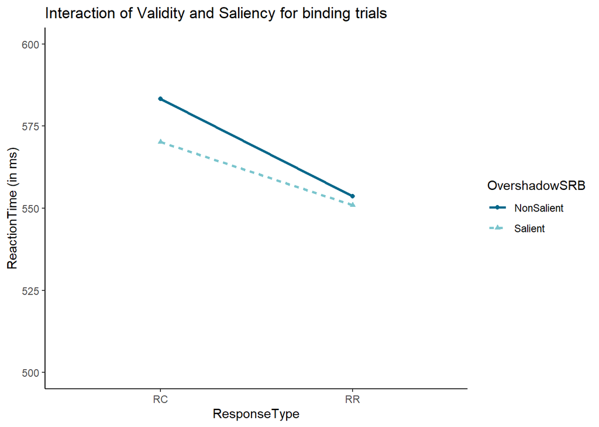

- **ANOVA**:

  | Effect | DFn | DFd | SSn | SSd | F | p | p<.05 | ges |
  | --- | --- | --- | --- | --- | --- | --- | --- | --- |
  | (Intercept) | 1 | 69 | 87908485 | 785605 | 7721 | 1.462e-72 | * | 0.9867 |
  | OvershadowSRB | 1 | 69 | 758.1 | 115446 | 0.4531 | 0.5031 |  | 0.0006414 |
  | Validity | 1 | 69 | 13708 | 146069 | 6.475 | 0.01318 | * | 0.01147 |
  | OvershadowSRB:Validity | 1 | 69 | 170.4 | 134178 | 0.08765 | 0.7681 |  | 0.0001443 |

```
## $`--- ANOVA RESULTS     ------------------------------------`
##                   Effect       MSE df1 df2       F     p petasq getasq
## 1            (Intercept) 11385.575   1  69 7721.04 0.000   0.99   0.99
## 2          OvershadowSRB  1673.128   1  69    0.45 0.503   0.01   0.00
## 3               Validity  2116.938   1  69    6.48 0.013   0.09   0.01
## 4 OvershadowSRB:Validity  1944.605   1  69    0.09 0.768   0.00   0.00
##
## $`--- SPHERICITY TESTS  ------------------------------------`
## [1] "N/A"
##
## $`--- FORMATTED RESULTS ------------------------------------`
##                   Effect                                    Text
## 1            (Intercept) F(1, 69) = 7721.04, p < .001, np2 = .99
## 2          OvershadowSRB F(1, 69) =    0.45, p = .503, np2 = .01
## 3               Validity F(1, 69) =    6.48, p = .013, np2 = .09
## 4 OvershadowSRB:Validity F(1, 69) =    0.09, p = .768, np2 < .01
##
## $`NOTE:`
## [1] "Reporting unadjusted p-values."
```

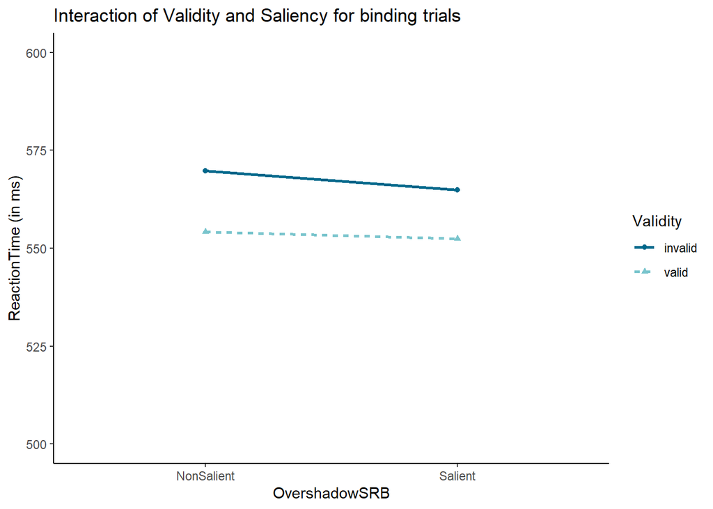

#### 2. Error Rate as DV

- **ANOVA**:

  | Effect | DFn | DFd | SSn | SSd | F | p | p<.05 | ges |
  | --- | --- | --- | --- | --- | --- | --- | --- | --- |
  | (Intercept) | 1 | 69 | 1.025 | 1.251 | 56.54 | 1.511e-10 | * | 0.2426 |
  | ResponseType | 1 | 69 | 0.01865 | 0.6504 | 1.979 | 0.164 |  | 0.005797 |
  | OvershadowSRB | 1 | 69 | 0.002423 | 0.6429 | 0.2601 | 0.6117 |  | 0.000757 |
  | ResponseType:OvershadowSRB | 1 | 69 | 0.001616 | 0.6551 | 0.1702 | 0.6812 |  | 0.0005049 |

#### 3. Inverse Efficiency scores

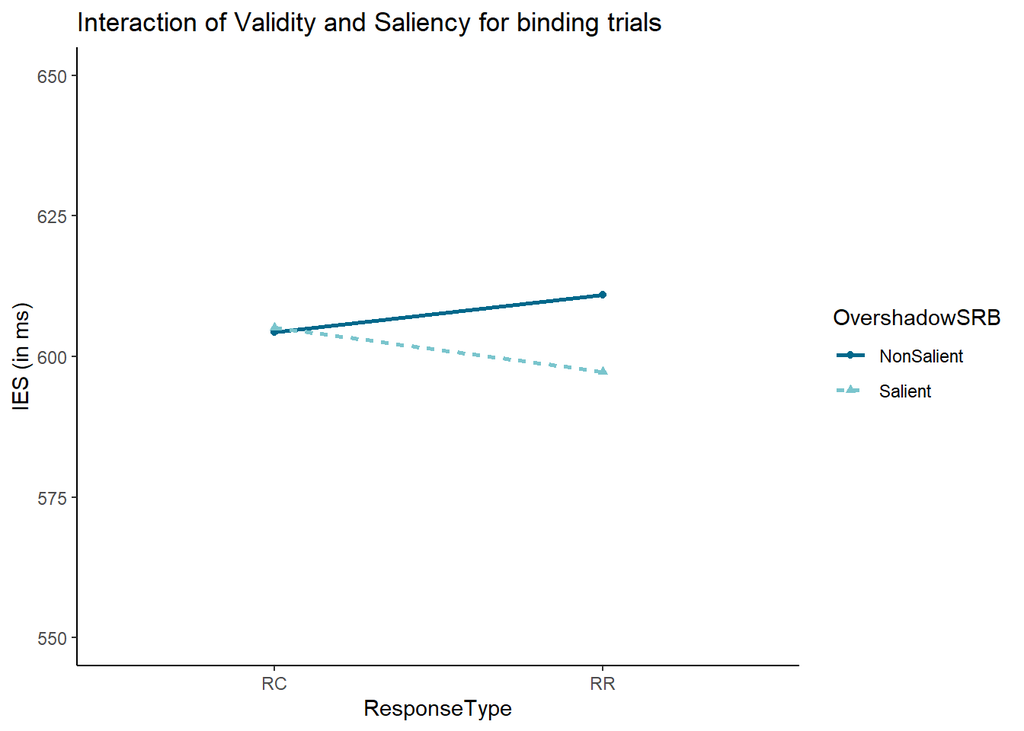

### 2. Previous Occurrence Distance

The distance of the last occurrence is computed as a new variable. It can range from 1, where the last occurrence was the immediate preceding on up until 20 where the last occurrence of that stimulus was 20 trials ago

Table showing the number of immediate previous occurence

| 1 |
| --- |
| 13275 |

Table showing the number of total previous occurences and how far each of them are

| 1 | 2 | 3 | 4 | 5 | 6 | 7 | 8 | 9 | 10 | 11 | 12 | 13 | 14 | 15 | 16 | 17 | 18 | 20 |
| --- | --- | --- | --- | --- | --- | --- | --- | --- | --- | --- | --- | --- | --- | --- | --- | --- | --- | --- |
| 13275 | 7201 | 4045 | 2138 | 1080 | 556 | 322 | 169 | 71 | 48 | 31 | 11 | 6 | 9 | 7 | 2 | 2 | 1 | 1 |

#### Removing only immediate previous occurences

To check if these immediate previous occurrences influence the overall validity effect a dateframe filtering out the Distance == 1 is created and analysed

The validity effect is reduced from p < .001 to p = 0.07

- **ANOVA**:

  | Effect | DFn | DFd | SSn | SSd | F | p | p<.05 | ges |
  | --- | --- | --- | --- | --- | --- | --- | --- | --- |
  | (Intercept) | 1 | 69 | 90455011 | 914862 | 6822 | 1.005e-70 | * | 0.9866 |
  | Saliency | 1 | 69 | 34.53 | 99328 | 0.02399 | 0.8774 |  | 2.82e-05 |
  | Validity | 1 | 69 | 4674 | 97432 | 3.31 | 0.07319 |  | 0.003803 |
  | Saliency:Validity | 1 | 69 | 516 | 112704 | 0.3159 | 0.5759 |  | 0.0004213 |

```
## $`--- ANOVA RESULTS     ------------------------------------`
##              Effect       MSE df1 df2       F     p petasq getasq
## 1       (Intercept) 13258.870   1  69 6822.23 0.000   0.99   0.99
## 2          Saliency  1439.542   1  69    0.02 0.877   0.00   0.00
## 3          Validity  1412.052   1  69    3.31 0.073   0.05   0.00
## 4 Saliency:Validity  1633.395   1  69    0.32 0.576   0.00   0.00
##
## $`--- SPHERICITY TESTS  ------------------------------------`
## [1] "N/A"
##
## $`--- FORMATTED RESULTS ------------------------------------`
##              Effect                                    Text
## 1       (Intercept) F(1, 69) = 6822.23, p < .001, np2 = .99
## 2          Saliency F(1, 69) =    0.02, p = .877, np2 < .01
## 3          Validity F(1, 69) =    3.31, p = .073, np2 = .05
## 4 Saliency:Validity F(1, 69) =    0.32, p = .576, np2 < .01
##
## $`NOTE:`
## [1] "Reporting unadjusted p-values."
```

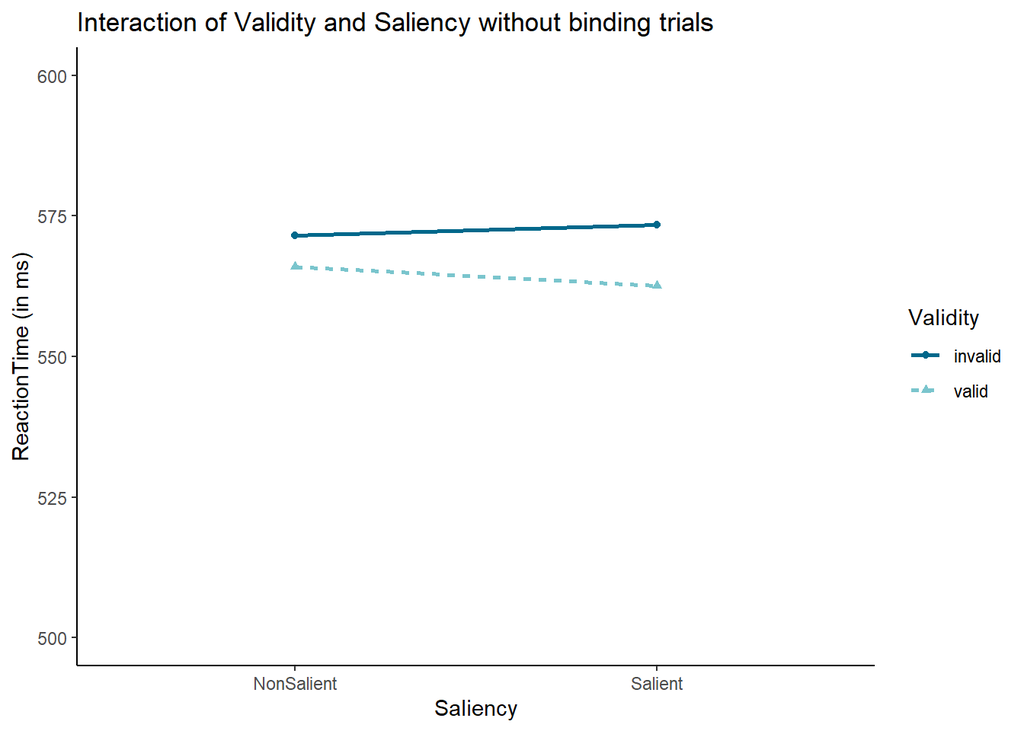

| Saliency | N | Mean | SD | FLSD |
| --- | --- | --- | --- | --- |
| NonSalient | 70 | 5.456 | 54.48 | 19.27 |
| Salient | 70 | 10.89 | 55.88 | 19.27 |

How strong are these effects?

t test for validity effect for salient trials

| Test statistic | df | P value | Alternative hypothesis | mean of the differences |
| --- | --- | --- | --- | --- |
| 1.63 | 69 | 0.1077 | two.sided | 10.89 |

| Test statistic | df | P value | Alternative hypothesis | mean of the differences |
| --- | --- | --- | --- | --- |
| 0.838 | 69 | 0.4049 | two.sided | 5.456 |

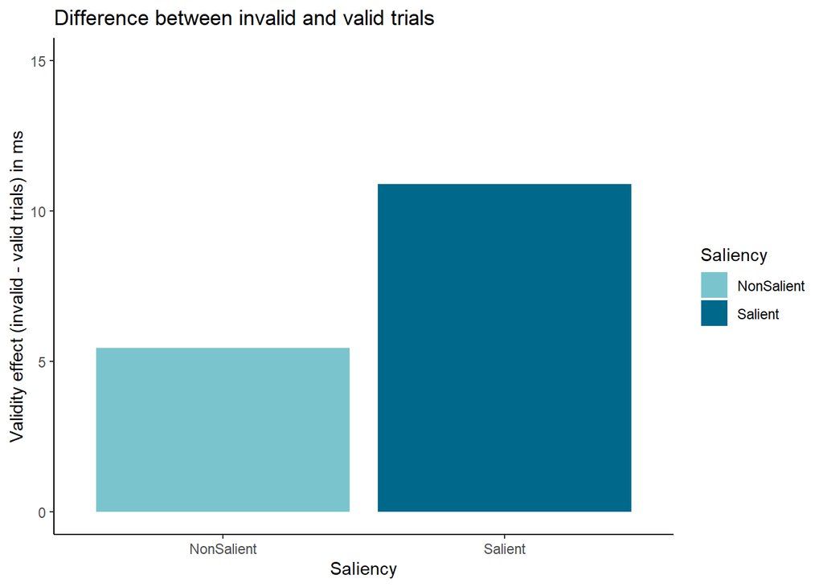

### Multi level modelling for last occurence distance

```r
# Exp6agg_Distance <- aggregate(data = Exp6data, RT_io~Validity+Saliency+participant+Distance+ResponseType,subset = (Condition == "test"), mean)
#
# interceptOnly <- gls(RT_io~1,
#                      data=Exp6agg_Distance,
#                      method = "ML",
#                      na.action= "na.omit")
#
# summary(interceptOnly)
#
# ##Now Adding the within-participant factor
# randomIntercept<-lmer(RT_io~1 + (1|participant),
#              data=Exp6agg_Distance,
#              REML=F,
#              na.action = "na.omit")
# summary(randomIntercept)
#
# #Level 1predictor: Validity - valid vs invalid, within participants
#
# randomIntercept_p1<-lmer(RT_io~1+Validity + (1+Validity|participant),
#                          data=Exp6agg_Distance,
#                          REML=F,
#                          na.action = "na.omit")
#
# summary(randomIntercept_p1)
# anova(randomIntercept_p1)
#
# #add saliency as level 1 predictor to model ####
# randomIntercept_p2<-lmer(RT_io~1+Saliency + Validity + (1+Saliency + Validity|participant),
#                          data=Exp6agg_Distance,
#                          REML=F,
#                          na.action = "na.omit")
# summary(randomIntercept_p2)
# anova(randomIntercept_p2)
#
#
# ##Adding previous response as a level 1 predictor
# randomIntercept_p3<-lmer(RT_io~1+Saliency + Validity + ResponseType + (1+Saliency + Validity+ResponseType|participant),
#                          data=Exp6agg_Distance,
#                          REML=F,
#                          na.action = "na.omit")
# summary(randomIntercept_p3)
# anova(randomIntercept_p3)
#
# ## adding interaction
#   randomIntercept_p4<-lmer(RT_io~ 1+Saliency*Validity*ResponseType+ (1+Validity*Saliency*ResponseType|participant),
#                            data=Exp6agg_Distance,
#                            REML=F,
#                            na.action = "na.omit")
#
#   summary(randomIntercept_p4)
#   anova(randomIntercept_p4)
#
## adding distance as a factor
```